# Analisis Data Pembangunan Wilayah Indonesia

2026-06-04

## Tujuan Analisis

- Memahami struktur dan karakteristik dataset pembangunan wilayah Indonesia
- Mengidentifikasi **missing value** dan **outlier**
- Melakukan statistika deskriptif dan visualisasi data
- Menggunakan konsep probabilitas dan distribusi data
- Menganalisis hubungan antar variabel

## Dataset

## Gambaran Dataset

```
## 'data.frame':    2500 obs. of  13 variables:
##  $ wilayah          : chr  "Kabupaten/Kota_1" "Kabupaten/Kota_2" "Kabupaten/Kota_3" "Kabupaten/Kota_4" ...
##  $ provinsi         : chr  "Jawa Barat" "Jawa Timur" "Kalimantan Timur" "DKI Jakarta" ...
##  $ tahun            : int  2022 2022 2020 2022 2023 2020 2024 2023 2023 2020 ...
##  $ pdrb_perkapita   : num  3.84e+07 1.66e+08 2.68e+07 1.55e+08 1.99e+08 ...
##  $ kemiskinan       : num  19.69 9.68 4.13 20.43 14.39 ...
##  $ pengangguran     : num  4.73 4.43 2.99 3.9 12.15 ...
##  $ ipm              : num  80.2 55 78.7 73.3 72.9 ...
##  $ harapan_hidup    : num  75.8 67.8 60.4 69.5 75 ...
##  $ rata_lama_sekolah: num  8.41 5.79 13.2 12.28 9.69 ...
##  $ akses_internet   : num  63.9 66.6 64.7 44.6 52.7 ...
##  $ jalan_baik       : num  53.9 34.9 48.6 57.9 65.7 ...
##  $ air_bersih       : num  43.1 58.9 90.3 86.2 90.8 ...
##  $ catatan_data     : chr  "Normal" "Normal" "Normal" "Normal" ...
```

## Dimensi & Variabel

**2500 observasi · 13 variabel · 10 provinsi · 2020–2024**

| Variabel | Tipe | Keterangan |
| --- | --- | --- |
| `wilayah`, `provinsi` | Character | Identitas wilayah |
| `tahun` | Integer | Tahun pengamatan |
| `pdrb_perkapita` | Numeric | PDRB per kapita (Rp) |
| `kemiskinan`, `pengangguran` | Numeric | Tingkat (%) |
| `ipm`, `harapan_hidup`, `rata_lama_sekolah` | Numeric | Indikator sosial |
| `akses_internet`, `jalan_baik`, `air_bersih` | Numeric | Infrastruktur (%) |
| `catatan_data` | Character | Normal / Missing Value / Outlier |

## Statistika Deskriptif

## Ringkasan Statistik

|  | Mean | Median | SD | Min | Max |
| --- | --- | --- | --- | --- | --- |
| tahun | 2022.00 | 2022.00 | 1.43 | 2020.00 | 2.024000e+03 |
| pdrb_perkapita | 135650462.48 | 137310624.00 | 89341269.95 | 15031581.00 | 1.774545e+09 |
| kemiskinan | 13.72 | 13.72 | 6.89 | 2.01 | 6.753000e+01 |
| pengangguran | 8.05 | 8.23 | 4.26 | 1.01 | 4.704000e+01 |
| ipm | 69.90 | 69.89 | 8.54 | 55.01 | 8.499000e+01 |
| harapan_hidup | 69.13 | 69.30 | 5.17 | 60.01 | 7.799000e+01 |
| rata_lama_sekolah | 9.58 | 9.52 | 2.63 | 5.02 | 1.400000e+01 |
| akses_internet | 58.79 | 58.09 | 22.82 | 0.01 | 9.799000e+01 |
| jalan_baik | 65.26 | 65.02 | 20.37 | 30.01 | 9.995000e+01 |
| air_bersih | 69.76 | 69.68 | 17.50 | 40.03 | 9.999000e+01 |

## Missing Value

## Identifikasi Missing Value

| Variabel | Jumlah_NA | Persentase |
| --- | --- | --- |
| wilayah | 0 | 0.00 |
| provinsi | 0 | 0.00 |
| tahun | 0 | 0.00 |
| pdrb_perkapita | 25 | 1.00 |
| kemiskinan | 24 | 0.96 |
| pengangguran | 25 | 1.00 |
| ipm | 25 | 1.00 |
| harapan_hidup | 0 | 0.00 |
| rata_lama_sekolah | 0 | 0.00 |
| akses_internet | 25 | 1.00 |
| jalan_baik | 25 | 1.00 |
| air_bersih | 0 | 0.00 |
| catatan_data | 0 | 0.00 |

## Penanganan: Median Imputation

**Mengapa median, bukan mean?**

```r
cat("Sisa missing value setelah imputasi:\n")
```

```
## Sisa missing value setelah imputasi:
```

```r
colSums(is.na(data_clean))
```

```
##           wilayah          provinsi             tahun    pdrb_perkapita
##                 0                 0                 0                 0
##        kemiskinan      pengangguran               ipm     harapan_hidup
##                 0                 0                 0                 0
## rata_lama_sekolah    akses_internet        jalan_baik        air_bersih
##                 0                 0                 0                 0
##      catatan_data
##                 0
```

## Outlier

## Metode Deteksi: IQR

**Batas outlier:**

- Batas bawah = Q1 − 1.5 × IQR
- Batas atas = Q3 + 1.5 × IQR

| Variabel | Jumlah_Outlier |
| --- | --- |
| tahun | 0 |
| pdrb_perkapita | 5 |
| kemiskinan | 5 |
| pengangguran | 5 |
| ipm | 0 |
| harapan_hidup | 0 |
| rata_lama_sekolah | 0 |
| akses_internet | 0 |
| jalan_baik | 0 |
| air_bersih | 0 |

## Interpretasi Outlier

[output not shown]

**Dampak:** distorsi mean, memperbesar varians, menyimpangkan korelasi

## Visualisasi

## Distribusi IPM

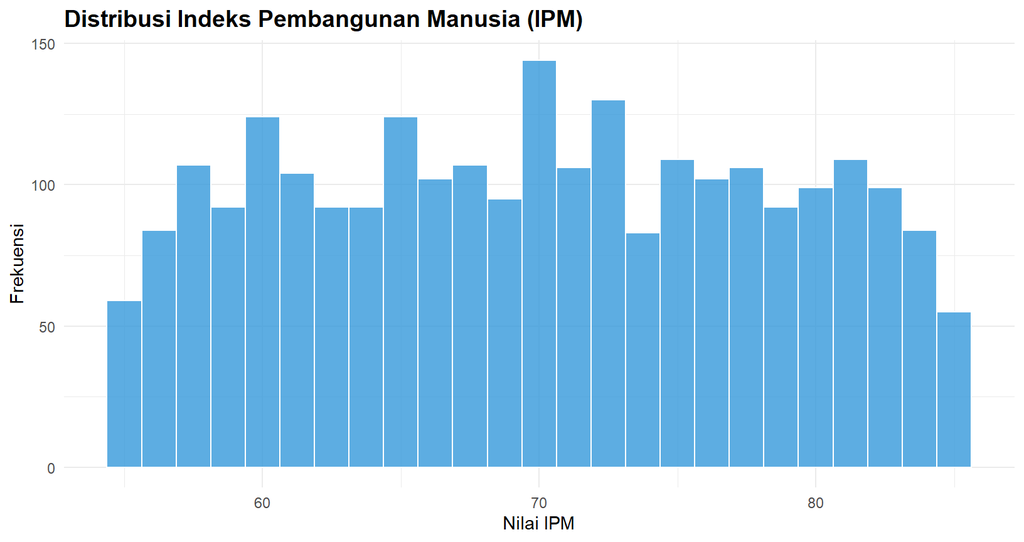

## Boxplot Tingkat Kemiskinan

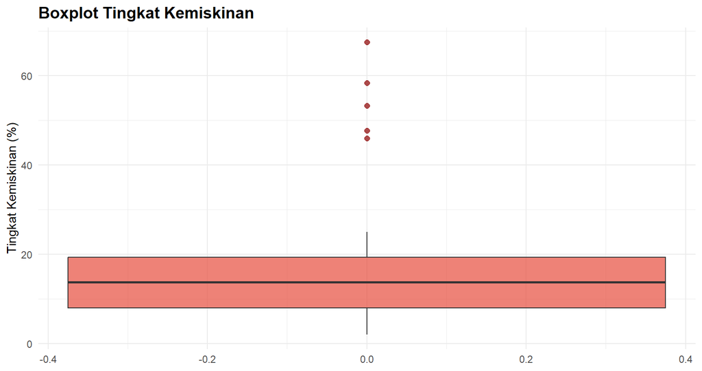

> Median ~13.5% · IQR ~7.5–20% · Distribusi *positively skewed*

## Hubungan IPM dan Kemiskinan

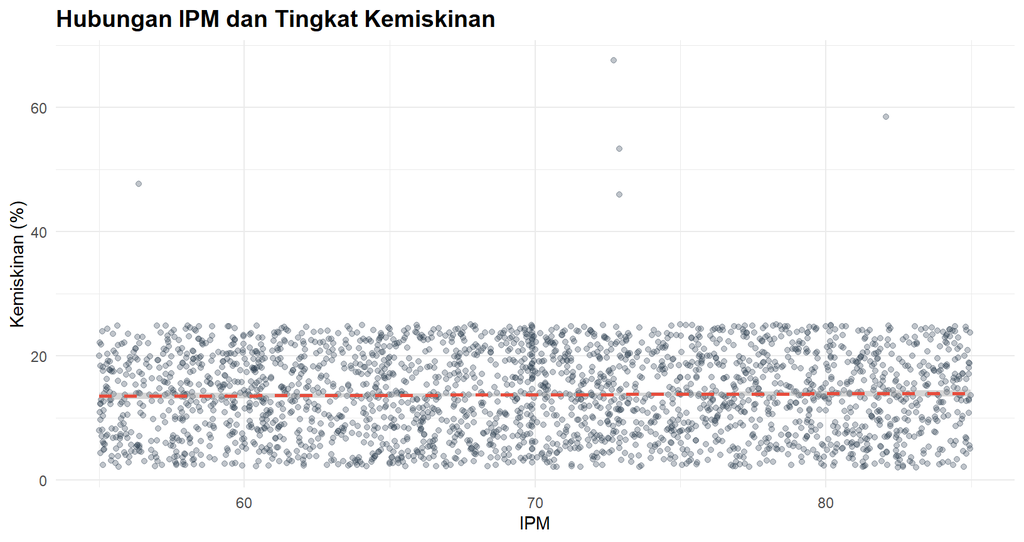

> Secara teori: korelasi negatif (IPM ↑ → kemiskinan ↓) · Pola lemah karena data sintetis

## Observasi per Provinsi

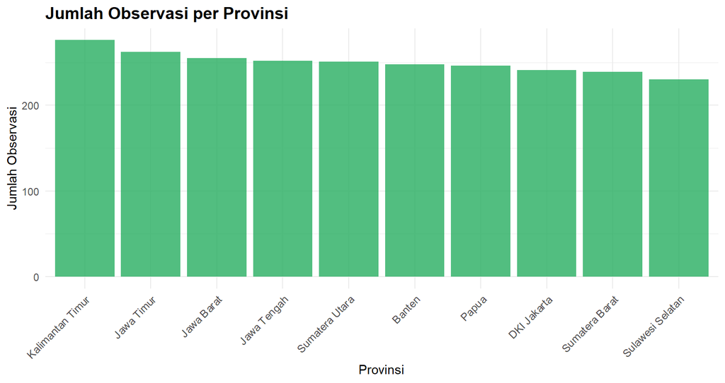

> Dataset *balanced* ~250 obs/provinsi · Perbandingan antar provinsi valid

## Distribusi Pengangguran

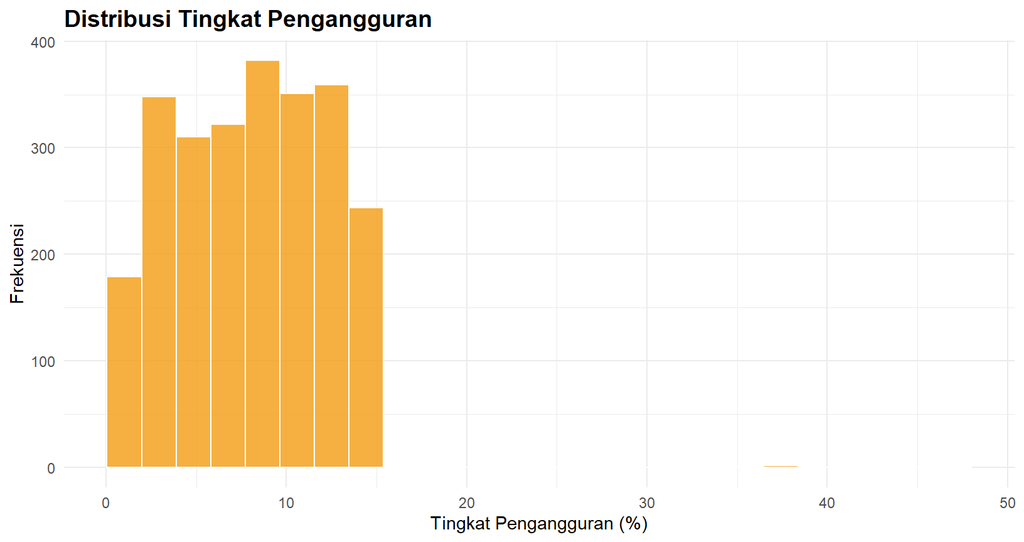

> Distribusi relatif merata pada 1–15% · Outlier di atas 15% terlihat jelas

## Heatmap Korelasi

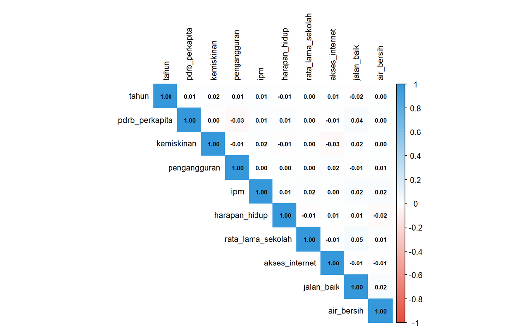

> Biru = korelasi positif · Merah = korelasi negatif · Nilai ≈ 0 → hubungan sangat lemah

## Probabilitas & Distribusi

## Uji Normalitas IPM (Shapiro-Wilk)

**H₀:** Data berdistribusi normal · **H₁:** Tidak normal · α = 0.05

```r
set.seed(123)
shapiro_result <- shapiro.test(sample(data_clean$ipm, 500))
shapiro_result
```

```
##
##  Shapiro-Wilk normality test
##
## data:  sample(data_clean$ipm, 500)
## W = 0.95722, p-value = 7.276e-11
```

[output not shown]

## Probabilitas Empiris

```
## P(kemiskinan > rata-rata 13.7%)  = 0.49  → 49.4% wilayah
```

```
## P(IPM > 75)                        = 0.32  → 31.9% wilayah
```

```
## P(pengangguran > 10%)             = 0.36  → 36.2% wilayah
```

## Probabilitas dengan Distribusi Normal

```r
mean_ipm <- mean(data_clean$ipm)
sd_ipm   <- sd(data_clean$ipm)

prob_ipm_80 <- 1 - pnorm(80, mean = mean_ipm, sd = sd_ipm)
ipm_p90     <- qnorm(0.90, mean = mean_ipm, sd = sd_ipm)

cat(sprintf("P(IPM > 80) berdasarkan distribusi normal = %.4f\n", prob_ipm_80))
```

```
## P(IPM > 80) berdasarkan distribusi normal = 0.1172
```

```r
cat(sprintf("Nilai IPM pada persentil ke-90            = %.2f\n", ipm_p90))
```

```
## Nilai IPM pada persentil ke-90            = 80.78
```

## Korelasi

## Matriks Korelasi

|  | tahun | pdrb_perkapita | kemiskinan | pengangguran | ipm | harapan_hidup | rata_lama_sekolah | akses_internet | jalan_baik | air_bersih |
| --- | --- | --- | --- | --- | --- | --- | --- | --- | --- | --- |
| tahun | 1.000 | 0.009 | 0.017 | 0.015 | 0.013 | -0.008 | 0.004 | 0.009 | -0.017 | 0.002 |
| pdrb_perkapita | 0.009 | 1.000 | -0.005 | -0.032 | 0.011 | 0.012 | -0.003 | -0.006 | 0.035 | 0.005 |
| kemiskinan | 0.017 | -0.005 | 1.000 | -0.009 | 0.020 | -0.014 | 0.002 | -0.031 | 0.020 | 0.001 |
| pengangguran | 0.015 | -0.032 | -0.009 | 1.000 | 0.000 | 0.001 | 0.002 | 0.020 | -0.009 | 0.007 |
| ipm | 0.013 | 0.011 | 0.020 | 0.000 | 1.000 | 0.010 | 0.018 | 0.002 | 0.023 | 0.023 |
| harapan_hidup | -0.008 | 0.012 | -0.014 | 0.001 | 0.010 | 1.000 | -0.012 | 0.009 | 0.006 | -0.020 |
| rata_lama_sekolah | 0.004 | -0.003 | 0.002 | 0.002 | 0.018 | -0.012 | 1.000 | -0.005 | 0.049 | 0.014 |
| akses_internet | 0.009 | -0.006 | -0.031 | 0.020 | 0.002 | 0.009 | -0.005 | 1.000 | -0.005 | -0.010 |
| jalan_baik | -0.017 | 0.035 | 0.020 | -0.009 | 0.023 | 0.006 | 0.049 | -0.005 | 1.000 | 0.024 |
| air_bersih | 0.002 | 0.005 | 0.001 | 0.007 | 0.023 | -0.020 | 0.014 | -0.010 | 0.024 | 1.000 |

## Uji Korelasi

| Pasangan | r | p_value | Signifikan |
| --- | --- | --- | --- |
| IPM ~ Kemiskinan | 0.0196 | 0.3267 | FALSE |
| IPM ~ Akses Internet | 0.0021 | 0.9160 | FALSE |
| PDRB ~ Kemiskinan | -0.0047 | 0.8148 | FALSE |

**Panduan:** |r| 0–0.19 sangat lemah · 0.20–0.39 lemah · 0.40–0.59 sedang · 0.60–0.79 kuat · 0.80+ sangat kuat

## Kesimpulan

## Temuan Utama

| Aspek | Temuan |
| --- | --- |
| **IPM** | Rata-rata ~sedang; ~32% wilayah IPM > 75 |
| **Kemiskinan** | ~49% wilayah di atas rata-rata nasional |
| **Pengangguran** | ~36% wilayah > 10% |
| **Ketimpangan** | PDRB per kapita sangat bervariasi → kesenjangan ekonomi besar |
| **Digital divide** | Akses internet 0–98% → kesenjangan digital nyata |

## Rekomendasi

1. **Wilayah IPM < 60** — alokasi sumber daya lebih besar untuk pendidikan & kesehatan
2. **Infrastruktur digital** — prioritas di wilayah akses internet rendah
3. **Pengentasan kemiskinan** — perluas bantuan sosial dan pemberdayaan ekonomi
4. **Ketenagakerjaan** — program pelatihan kerja dan dukungan UMKM
5. **Kualitas data** — perbaiki sistem pengumpulan untuk meminimalisir missing value

## Referensi

- Walpole et al. (2012). *Probability & Statistics for Engineers & Scientists*, 9th ed.
- Wickham (2016). *ggplot2: Elegant Graphics for Data Analysis*.
- BPS (2023). *Indeks Pembangunan Manusia 2023*.
- Field (2013). *Discovering Statistics Using R*.
- James et al. (2013). *An Introduction to Statistical Learning with Applications in R*.